# GWAS Bootcamp

Introduction to Phenotypic Analyses

Felipe Ferrão

University of Florida – July, 2022

**Objectives:**

- 20 minutes of hands-on
- Using R for analyses of phenotypic data

**Extra information**

- [HOS 6932 – Website](https://lfelipe-ferrao.github.io/class/survey/)
- About the [author](https://lfelipe-ferrao.github.io/)
- About the [UF/IFAS Plant Breeding](https://programs.ifas.ufl.edu/plant-breeding/)

# Introduction

Any analysis of association between genotype and phenotype starts with the collection of good phenotypic data and adequate statistical analysis. Collecting good phenotypic data is not just about being careful when measuring a certain trait either in the field or in the laboratory, but it also involves good experimental practices. Therefore, whenever possible, well-designed experiments including repetitions, casualization and local control (if necessary); should be prioritized. Such aspects will certainly affect downstream results associated to GWAS analyses. In this short tutorial we will consider different experimental analyses, using different approaches.

We will follow the general structure:

- We will consider a case of study (real data in blueberry)
- Run simple descriptive analyses
- Generate some genotypic metrics
- Check the possibility to use post-hoc analysis for the blueberry example
- General idea about experimental desing

Important R packages:

- `dplyr`: data wrangling
- `ggplot`: data visualisation
- `asreml-R`: fitting mixed models

## Short introduction about Linear Mixed Models

- More details, you can find in the [link from the PCB6555 class](https://htmlpreview.github.io/?https://github.com/lfelipe-ferrao/lfelipe-ferrao.github.io/blob/master/class/quantGenetic/week4.html)

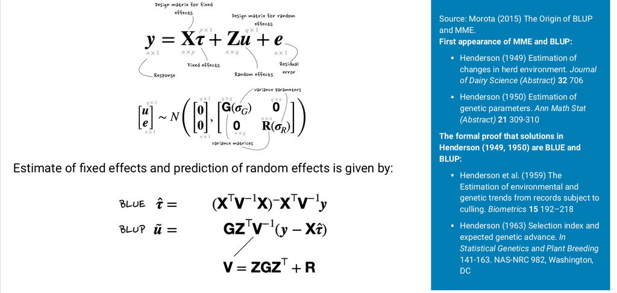

Slide from [Emi Tanaka](https://emitanaka.org/teaching.html)

- `ASReml-R` is a commercial software that fit linear mixed models using residual maximum likelihood with average information algorithm.
- Basic syntax structure of ASReml-R:

```
asreml(response ~ fixed_expr, random=~ random_expr, rcov=~ rcov_expr)
```

# Phenotypic Analyses

## Descriptive Analyses

**Questions:**

- What is the distribution of the data?
- Are there very contrasting values? If so, would they be outliers or indeed promising phenotypes?
- Does my data need to be transformed? What transformation?
- Do I have missing data?

**Data set:**

- Blueberry breeding population (n=1886)
- Data collected over two years
- Average value of five berries per plant
- Firmness data used for [estimating genetic parameters](https://link.springer.com/article/10.1007/s10681-018-2165-8) and for GWAS analyses.
- `2015.1` is a fake year that I included a typo

```r
# Downloading the data
library(ggplot2)
library(dplyr)
library(openxlsx)

firmness = read.xlsx("/home/lferrao/Dropbox (UFL)/classes/gwas_tutorial/1.Phenotypic/hands_on1/blueberry_firmness.xlsx")
firmness$year = as.factor(firmness$year)
firmness$tree = as.factor(firmness$tree)
str(firmness)
```

```
## 'data.frame':    3772 obs. of  5 variables:
##  $ tree: Factor w/ 1886 levels "13.100.1","13.100.10",..: 1130 1139 1140 1141 1142 1143 1144 1145 1146 1131 ...
##  $ year: Factor w/ 2 levels "2014","2015": 1 1 1 1 1 1 1 1 1 1 ...
##  $ col : num  1 1 1 1 1 1 1 1 2 2 ...
##  $ row : num  10 12 18 19 30 32 37 44 3 6 ...
##  $ firm: num  223 246 224 278 218 ...
```

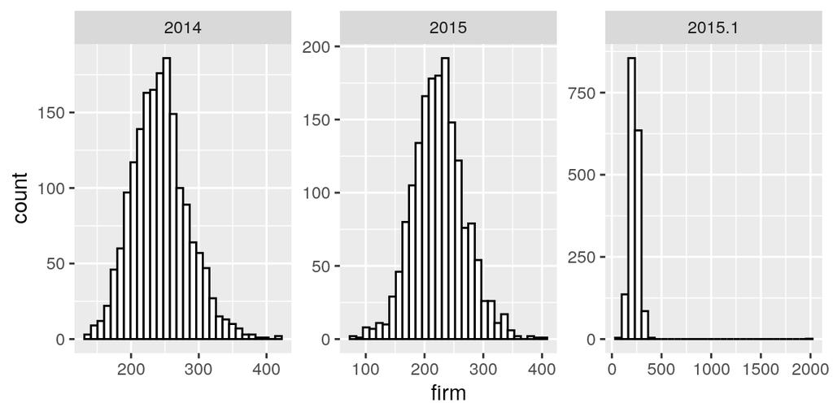

```r
# Ploting the data
firmness2 = read.xlsx("/home/lferrao/Dropbox (UFL)/classes/gwas_tutorial/1.Phenotypic/hands_on1/blueberry_firmness.xlsx", sheet = 3)
ggplot(firmness2,aes(x=firm))+
  geom_histogram(color="black", fill="white")+
  facet_wrap(~year, scales = "free")
```

```r
# Summarizing the data
firmness %>%
  group_by(year)%>%
  summarize(Mean = mean(firm, na.rm=TRUE),
            Median= median(firm, na.rm=TRUE),
            SD =sd(firm, na.rm=TRUE),
            Min.=min(firm, na.rm=TRUE),
            Max.=max(firm, na.rm=TRUE),
            MissingData = sum(is.na(firm)),
            Datapoint = n(),
            Final = Datapoint-MissingData)
```

```
## # A tibble: 2 × 9
##   year   Mean Median    SD  Min.  Max. MissingData Datapoint Final
##   <fct> <dbl>  <dbl> <dbl> <dbl> <dbl>       <int>     <int> <int>
## 1 2014   243.   241.  41.2 136.   417.         103      1886  1783
## 2 2015   225.   223.  44.2  78.8  404.         166      1886  1720
```

**Transformation**

- Nice discussion about transformation was presented in this [blog](https://www.r-bloggers.com/2020/01/a-guide-to-data-transformation/)
- Importance of transformation:
  - Improve interpretability
  - Meet assumptions for statistical inference

Some options:

| Automatic | Positive skewed data | Left skewed data |
| --- | --- | --- |
| LambertW | Root | x^2 |
| Box-COx | log(x) | Exponentional |
|  | 1/x |  |

## Statistical Model

**Modelling Process**

1. Understand the problem
2. Plan and collect the data
3. Explore the data (data visualization)
4. Postulate a model
5. Fit a model (least square, ML, REML, Bayesian)
6. Check the model (residuals, prediction, goodness-of-fit)
7. Go back to `iv` and try again
8. Use the model

### Fixed vs. Random Effects

Herein, we will consider different ways to model the genotypic effects. This discussion will start under the basis of a central equation in quantitative genetics where Phenotype = Genotype + Environment or just P=G+E. From here, we will focus on the G portion by constructing expressions that predict/estimate the genotypic value of the genotypes in the population. Simply stating, our central objective is to bring to GWAS analyses “corrected phenotypic values”, in which eventual associations with molecular markers have genetic causes and is not biased for eventual noises caused by environmental factors.

We will show four different metrics that can be computed and how (and why) they are more or less correlated. This discussion also involves definitions about fixed and random effects. Sometimes, the decision as to whether certain effects are fixed or random is not immediately obvious. In this [class (Linear Mixel Model)](https://htmlpreview.github.io/?https://github.com/lfelipe-ferrao/lfelipe-ferrao.github.io/blob/master/class/quantGenetic/week4.html), I present more details about this topic. Below, there is a simple table constrasting fixed and random effects.

|  | Fixed | Random |
| --- | --- | --- |
| Objectives | compare specific levels of a certain factor | conclusions draw for a larger universe of interest |
| Sampling | treatment levels are selected by the investigator | treatment levels are randomly sampled |
| Statistically | hypothesis tests on the mean $H_0: \tau_1 = \tau_2 = ...= \tau_n$ | hypothesis tests on the variance component $H_0: \sigma^2_{\tau} = 0$ |
| Number of observation | any | Rule of thumb: >5-10 |

### Genotypic Metrics

In this workshop, we will obtain four metrics associated to the “genotypic effect”.

- Raw mean
- BLUEs (when genotype effect is fixed)
- BLUPs (when genotype effect is random indexed by an Identity variance and covariance matrix)
- A-BLUPs (when genotype effect is random indexed by a pedigree)

```r
# Statistical model
# y = m + year + tree + e

library(asreml)

# Raw Mean across both years
firm.mean = firmness %>%
  group_by(tree)%>%
  summarise_if(is.numeric, mean, na.rm=T) %>%
  select(tree, firm) %>%
  mutate_if(is.numeric, ~ifelse(is.nan(.), NA, .)) %>%
  as.data.frame

# BLUEs
fm1 = asreml(fixed=firm ~ year + tree, data=firmness)
blues = predict(fm1, classify = "tree",pworkspace="10gb")

# BLUPs (identity matrix)
fm2 = asreml(fixed=firm ~ year,
             random = ~ tree, data=firmness)
blups = predict(fm2, classify = "tree",pworkspace="10gb")

# BLUPs (Amatrix)
ped = openxlsx::read.xlsx("/home/lferrao/Dropbox (UFL)//PosDoc_UF_NewGenome/DataSet/Pedigree/PedigreeV59.xlsx",sheet=1)[,1:3]
A = AGHmatrix::Amatrix(ped)
Afirm = A[as.character(unique(firmness$tree)),as.character(unique(firmness$tree))]
fm3 = asreml(fixed=firm ~ year,
             random = ~ vm(tree,Afirm), data=firmness)
A_blups = predict(fm3, classify = "tree",pworkspace="10gb")

# Combining all results
geno.metrics= data.frame(tree=firm.mean$tree,
  avg = firm.mean$firm,
  blue = blues$pvals$predicted.value,
  blups = blups$pvals$predicted.value)

geno.metrics = merge(geno.metrics,A_blups$pvals, by="tree") %>%
  select(-std.error, -status) %>%
  rename(A_blups = predicted.value)

save(geno.metrics, file="/home/lferrao/Dropbox (UFL)/classes/gwas_tutorial/1.Phenotypic/hands_on1/geno_metric.Rdata")
```

All the four metrics were saved in a single data frame. We have the following questions:

```r
load("/home/lferrao/Dropbox (UFL)/classes/gwas_tutorial/1.Phenotypic/hands_on1/geno_metric.Rdata")
```

**Regarding the `blue` and the `avg` value, why values are not the same?**

Values are not the same because the data is not balanced. When we have phenotypes collected in both years, `blues` and `raw.avg` will be the same (see the genotype `13.100.10`, for example). But in the case of trees with phenotypic data collected in single year, `blues` will be able to correct the phenotypic effect for the year effect.

```r
head(geno.metrics)
```

```
##        tree      avg     blue    blups  A_blups
## 1  13.100.1 175.2703 166.3639 217.1937 217.7470
## 2 13.100.10 238.4131 238.4131 235.9572 233.7745
## 3 13.100.11 216.4955 216.4955 226.2076 226.1992
## 4 13.100.12 278.9550 270.0486 246.8510 239.4087
## 5 13.100.13 241.2186 232.3122 236.0571 231.5248
## 6 13.100.14 232.6712 232.6712 233.4030 231.7900
```

```r
firmness %>%  filter(tree %in% c("13.100.1", "13.100.10")) %>%  select(tree,year, firm)
```

```
##        tree year     firm
## 1  13.100.1 2014 175.2703
## 2 13.100.10 2014 234.8282
## 3  13.100.1 2015       NA
## 4 13.100.10 2015 241.9980
```

**What is the correlation between the metrics?**

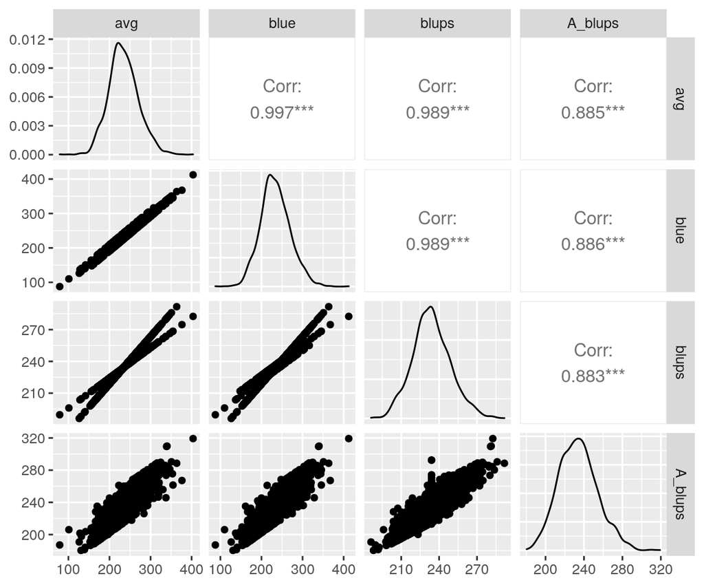

```r
library(GGally)
ggpairs(geno.metrics[,-1])
```

**Observations**

- Correlation between `avg`, `blues` and `blups` are very strong, even with moderate imbalance in the data set.
- In the case of missing data in both years, `avg` and `blue` will export `NA` data, while the `blups` will be able to predict a value for the missing value ( this value will be very similar to the general mean of both years, in this case that we have only the year effect in the model)
- I have seen papers using all these 3 metrics for downstream analyses related to genomic selection and GWAS studies.
- I would suggest to use the `blues`. To avoid double shrinkage of estimates
- The `A-blups` is in fact the most different metric. There are a couple os reasons for that. The main one is that the genotypic metrics will suffer a shrinkage dictated not only by the heritability of the trait, but also by pedigree. Pedigree allows the model to borrow information across genotypes. It makes some genotypes more similar to others depending on the genealogical relationship between them (and the pedigree depth).
- While pedigree blups is very beneficial for prediction purposes, some authors argue that it can cause bias in associative studies. For more details, check this [study](https://academic.oup.com/g3journal/article/4/2/341/6028832?login=true)

```r
# Try to remove the missing data
# tmp = firmness %>%
#   group_by(tree)%>%
#   summarize(MissingData = sum(is.na(firm))) %>%
#   filter(MissingData ==0)
#
# tmp1 = geno.metrics[tmp$tree,]
# ggpairs(tmp1[,-1])
```

## Outputs from the Phenotypic Analyses

**Step-by-step**:

- Fit an animal model per year and estimate genetic parameters
- Plot diagnostic
- Combine both years
- Fit the blues per year and combined

```r
# Year 1
y1 = firmness %>%  filter(year==2014) %>% droplevels()
mean(y1$firm,na.rm=T)
fm.y1 = asreml(fixed=firm ~ year, random = ~ vm(tree,Afirm), data=y1)
summary(fm.y1)$varcomp
vpredict(fm.y1,h2~V1/(V1+V2)) # 0.47
plot(fm.y1)

# Year 2
y2 = firmness %>%  filter(year==2015) %>% droplevels()
mean(y2$firm,na.rm=T)
fm.y2 = asreml(fixed=firm ~ year, random = ~ vm(tree,Afirm), data=y2)
summary(fm.y2)$varcomp
vpredict(fm.y2,h2~V1/(V1+V2)) #0.78
plot(fm.y2)
```

**Genetic parameters**

[output not shown]

**Final analyses**

$$y_{ij} = m + s_i + g_j + e_{ij}$$

In the `predict` function, we can specify `classify = "tree:year"` and estimate BLUEs for each year separately.

```r
library(asreml)
# Final Model
# BLUEs
fm.final = asreml(fixed=firm ~ year + tree, data=firmness)
```

```
## Model fitted using the gamma parameterization.
## ASReml 4.1.0 Thu Jul  7 17:47:16 2022
##           LogLik        Sigma2     DF     wall    cpu
##  1     -7281.135      1188.115   1659 17:47:21    4.7
```

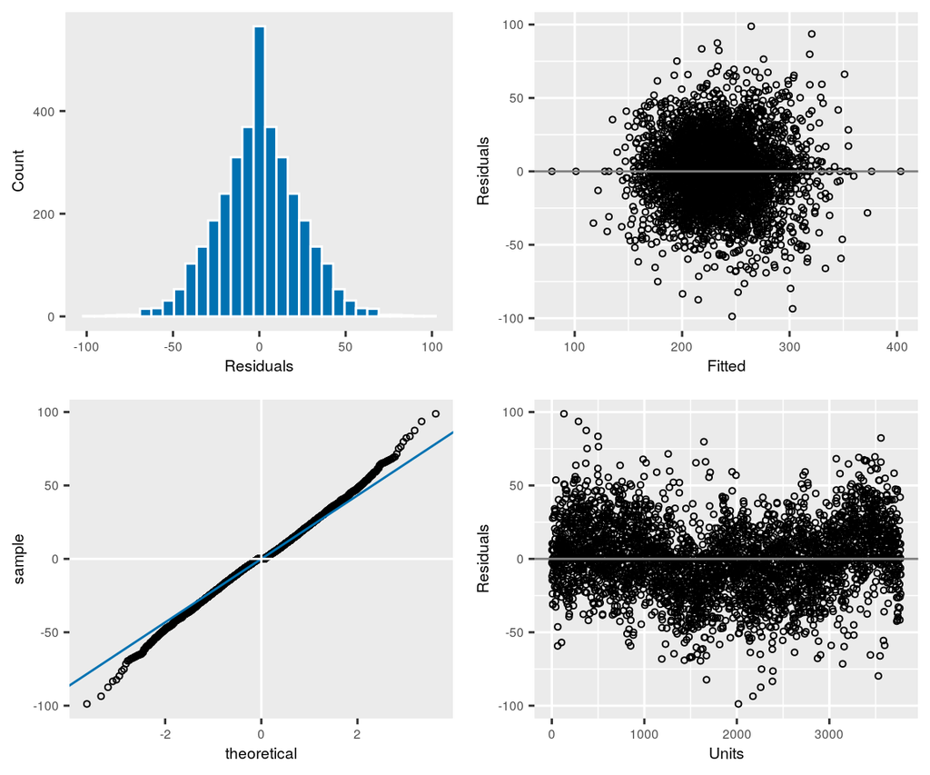

```r
plot(fm.final)
```

```r
# Estimating the BLUES
blues.combined = predict(fm1, classify = "tree",pworkspace="10gb") # common blues
blues.location = predict(fm1, classify = "tree:year",pworkspace="10gb") # blues per year
# Exported values will be used as input in future GWAS studies
```

## Unreplicated Trial and Spatial Analyses

In this topic we will deal with heterogeneity of errors in a post-hoc analysis, rather than in the experimental design. The use of spatial analyses can improve the estimation of genetic effects by modeling more accurately the spatial distribution of error effects in a field trial. Results can potentially improve downstream analyses related to genomic prediction and GWAS.

Below one example using the same data set, but using the size trait. Visually, is it possible to observe any phenotypic trends?

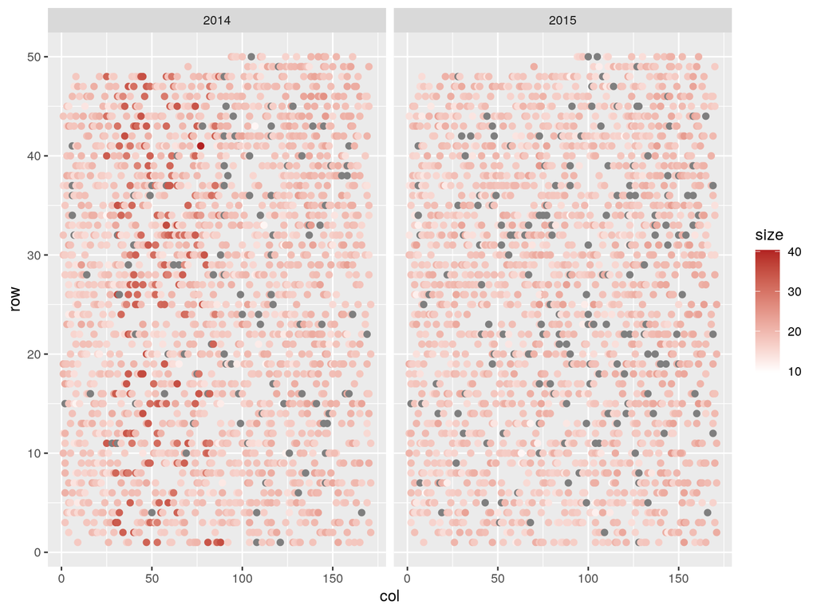

```r
size = read.xlsx("/home/lferrao/Dropbox (UFL)/classes/gwas_tutorial/1.Phenotypic/hands_on1/blueberry_firmness.xlsx", sheet=2)
ggplot(size, aes(col,row, color = size)) +
  geom_point(size=1.8)+
  scale_color_gradient(low = "white", high = "firebrick") +
  facet_wrap(~year,ncol=2)
```